# Time-To-Event Analysis

# AFT Model

[AFT Model](https://stat.ethz.ch/education/semesters/ss2011/seminar/contents/handout_9.pdf)

$$log(T) = \alpha_0 + \alpha_1 X + \epsilon$$

- log(T) = extreme value distribution: Exponential
- log(T) = extreme value distribution: Weibull, which has an additional parameter that scales $\epsilon$
- log(T) = logistic: log-logistic
- long(T) = normal: log-normal
- Accelerated time failure assumption: The probability of a dog surviving past t years is equal to a human surviving past 7*t years.
- AFT Models describe stretching out or contraction of survival time as a function of predictor variables.
- AFT assumption: S is survival, $\gamma$ is acceleration factor
  $$S_{non-treatment} = S_{treatment}(\gamma t)$$
  $$\gamma T_{non-treatment} = T_{treatment}$$
- $\gamma > 1$ exposure benefits survival

# Discrete Time Proportional Odds

## Data Simulation

- Assume average daily death rate of 5%
- Individual baseline death rate has a random effect has standard deviation of the half of the log odds
- The treatment effect of odds ratio 0.5
- Subjects are observed for 28 days

```r
library(Wu)

set.seed(123456)
n <- 1000
n0 <- 500
n1 <- n - n0

r_0 <- 0.05
odds_0 <- r_0 / (1 - r_0)
sd <- abs(log(odds_0) / 2)
odds_0s <- exp(rnorm(n0, log(odds_0), sd))
r_0s <- odds_0s / (1 + odds_0s)

or <- 0.5
odds_1 <- odds_0 * or
r_1 <- odds_1 / (1 + odds_1)
odds_1s <- exp(rnorm(n1, log(odds_1), sd))
r_1s <- odds_1s / (1 + odds_1s)

days <- 28
for(i in 1:days){
    print(i)
    event_i <- c(rbinom(n0, 1, r_0s), rbinom(n1, 1, r_1s))
    if(i == 1){
        t <- data.table(
            day=i
          , id=1:n
          , trt=rep(c(0, 1), each=c(n0, n1))
          , event=event_i
        )
        rtn <- copy(t)
    }else{
        event_i[t$event %in% c(1, NA)] <- NA
        t <- data.table(
            day=i
          , id=1:n
          , trt=rep(c(0, 1), each=c(n0, n1))
          , event=event_i
        )
        rtn <- rbind(rtn, t)
    }
}
```

[1] 1 [1] 2 [1] 3 [1] 4 [1] 5 [1] 6 [1] 7 [1] 8 [1] 9 [1] 10 [1] 11 [1] 12 [1] 13 [1] 14 [1] 15 [1] 16 [1] 17 [1] 18 [1] 19 [1] 20 [1] 21 [1] 22 [1] 23 [1] 24 [1] 25 [1] 26 [1] 27 [1] 28

```r
dim(rtn) %>% prt()
```

| x |
| --- |
| 28000 |
| 4 |

```r
rtn[, .N, by = .(day)][order(day)] %>% prt()
```

| day | N |
| --- | --- |
| 1 | 1000 |
| 2 | 1000 |
| 3 | 1000 |
| 4 | 1000 |
| 5 | 1000 |
| 6 | 1000 |
| 7 | 1000 |
| 8 | 1000 |
| 9 | 1000 |
| 10 | 1000 |
| 11 | 1000 |
| 12 | 1000 |
| 13 | 1000 |
| 14 | 1000 |
| 15 | 1000 |
| 16 | 1000 |
| 17 | 1000 |
| 18 | 1000 |
| 19 | 1000 |
| 20 | 1000 |
| 21 | 1000 |
| 22 | 1000 |
| 23 | 1000 |
| 24 | 1000 |
| 25 | 1000 |
| 26 | 1000 |
| 27 | 1000 |
| 28 | 1000 |

```r
rtn[, .N, by = .(day, trt)][order(day)] %>% prt()
```

| day | trt | N |
| --- | --- | --- |
| 1 | 0 | 500 |
| 1 | 1 | 500 |
| 2 | 0 | 500 |
| 2 | 1 | 500 |
| 3 | 0 | 500 |
| 3 | 1 | 500 |
| 4 | 0 | 500 |
| 4 | 1 | 500 |
| 5 | 0 | 500 |
| 5 | 1 | 500 |
| 6 | 0 | 500 |
| 6 | 1 | 500 |
| 7 | 0 | 500 |
| 7 | 1 | 500 |
| 8 | 0 | 500 |
| 8 | 1 | 500 |
| 9 | 0 | 500 |
| 9 | 1 | 500 |
| 10 | 0 | 500 |
| 10 | 1 | 500 |
| 11 | 0 | 500 |
| 11 | 1 | 500 |
| 12 | 0 | 500 |
| 12 | 1 | 500 |
| 13 | 0 | 500 |
| 13 | 1 | 500 |
| 14 | 0 | 500 |
| 14 | 1 | 500 |
| 15 | 0 | 500 |
| 15 | 1 | 500 |
| 16 | 0 | 500 |
| 16 | 1 | 500 |
| 17 | 0 | 500 |
| 17 | 1 | 500 |
| 18 | 0 | 500 |
| 18 | 1 | 500 |
| 19 | 0 | 500 |
| 19 | 1 | 500 |
| 20 | 0 | 500 |
| 20 | 1 | 500 |
| 21 | 0 | 500 |
| 21 | 1 | 500 |
| 22 | 0 | 500 |
| 22 | 1 | 500 |
| 23 | 0 | 500 |
| 23 | 1 | 500 |
| 24 | 0 | 500 |
| 24 | 1 | 500 |
| 25 | 0 | 500 |
| 25 | 1 | 500 |
| 26 | 0 | 500 |
| 26 | 1 | 500 |
| 27 | 0 | 500 |
| 27 | 1 | 500 |
| 28 | 0 | 500 |
| 28 | 1 | 500 |

```r
rtn[, .N, by = .(day, event)][order(day, event)] %>% prt()
```

| day | event | N |
| --- | --- | --- |
| 1 | 0 | 906 |
| 1 | 1 | 94 |
| 2 | 0 | 840 |
| 2 | 1 | 66 |
| 2 | NA | 94 |
| 3 | 0 | 801 |
| 3 | 1 | 39 |
| 3 | NA | 160 |
| 4 | 0 | 756 |
| 4 | 1 | 45 |
| 4 | NA | 199 |
| 5 | 0 | 728 |
| 5 | 1 | 28 |
| 5 | NA | 244 |
| 6 | 0 | 699 |
| 6 | 1 | 29 |
| 6 | NA | 272 |
| 7 | 0 | 668 |
| 7 | 1 | 31 |
| 7 | NA | 301 |
| 8 | 0 | 642 |
| 8 | 1 | 26 |
| 8 | NA | 332 |
| 9 | 0 | 616 |
| 9 | 1 | 26 |
| 9 | NA | 358 |
| 10 | 0 | 594 |
| 10 | 1 | 22 |
| 10 | NA | 384 |
| 11 | 0 | 575 |

[output cut: 53 more lines]

```r
dt <- copy(rtn)[!is.na(event)]
dim(dt)
```

[1] 16003 4

```r
dt <- dt[order(id, -day)
         ][, rn := 1:.N, by = .(id)
           ][rn == 1
             ][, rn := NULL]
dt[, .N, by = .(day, event)][order(day, event)]
```

day event N 1: 1 1 94 2: 2 1 66 3: 3 1 39 4: 4 1 45 5: 5 1 28 6: 6 1 29 7: 7 1 31 8: 8 1 26 9: 9 1 26 10: 10 1 22 11: 11 1 19 12: 12 1 21 13: 13 1 16 14: 14 1 17 15: 15 1 13 16: 16 1 18 17: 17 1 13 18: 18 1 18 19: 19 1 14 20: 20 1 9 21: 21 1 15 22: 22 1 7 23: 23 1 12 24: 24 1 12 25: 25 1 8 26: 26 1 8 27: 27 1 7 28: 28 0 365 29: 28 1 2 day event N

```r
dt <- dt[, censor := case_when(event == 0 ~ 1, TRUE ~ 0)]
```

## Kaplan Meier Plot

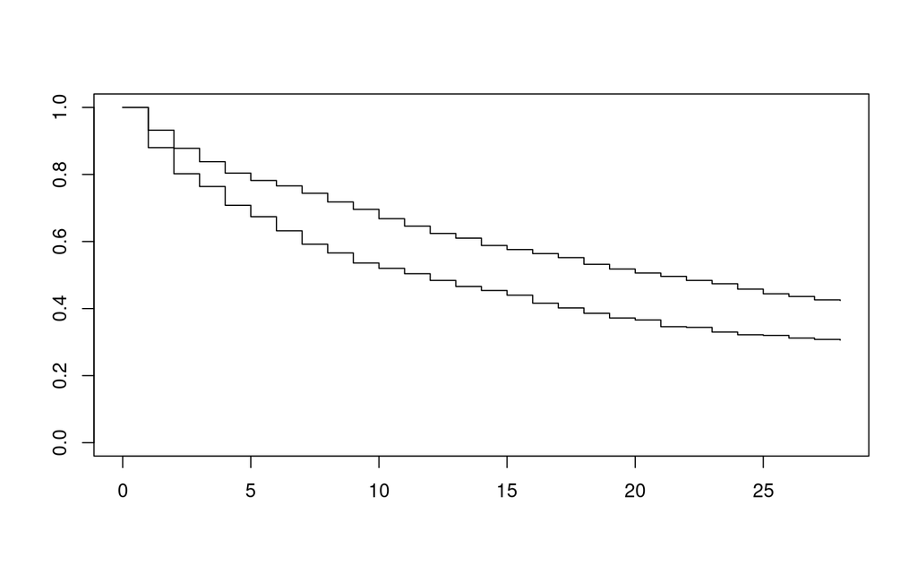

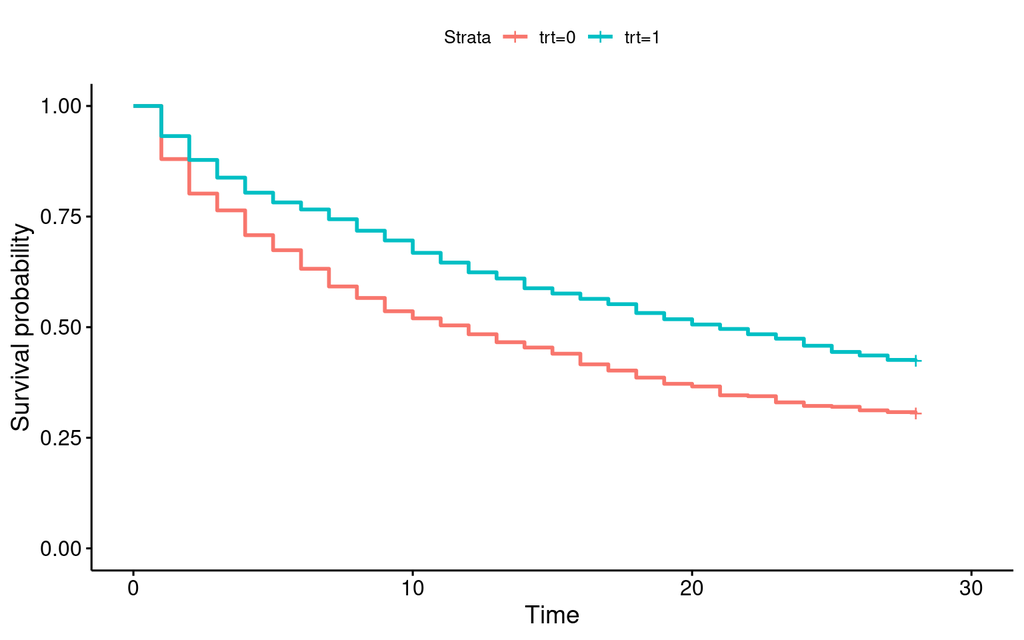

```r
library(survival)
library(survminer)

f <- survfit(Surv(day, event) ~ trt, data = dt)
plot(f)

ggsurvplot(f)
```

## Longitudinal Mixed-Effect Model R::lme4

```r
library(lme4)
dt <- copy(rtn)
dt <- dt[!is.na(event)]

t <- get_ors(outcome="event", predictor="trt", data=dt, digits = 3)
t

m <- glmer(event ~ trt + (1 | id)
         , data=dt
         , family = binomial(link="logit")
           )


summary(m)
```

Generalized linear mixed model fit by maximum likelihood (Laplace Approximation) [glmerMod] Family: binomial ( logit ) Formula: event ~ trt + (1 | id) Data: dt

AIC BIC logLik deviance df.resid 5201.2 5224.2 -2597.6 5195.2 16000

Scaled residuals: Min 1Q Median 3Q Max -0.4267 -0.2080 -0.1460 -0.1227 5.4049

Random effects: Groups Name Variance Std.Dev. id (Intercept) 1.681 1.296  
Number of obs: 16003, groups: id, 1000

Fixed effects: Estimate Std. Error z value Pr(>|z|)  
(Intercept) -2.86631 0.08675 -33.042 < 2e-16 *trt -0.63140 0.12564 -5.026 5.02e-07* — Signif. codes: 0 ‘**’ 0.001 ’**’ 0.01 ’’ 0.05 ‘.’ 0.1 ’ ’ 1

Correlation of Fixed Effects: (Intr) trt -0.685

```r
exp(fixef(m))
```

(Intercept) trt 0.05690833 0.53184909

## Bayesian Longitudinal Mixed-Effect Model R::brms

```r
library(brms)
dt <- copy(rtn)
dt <- dt[!is.na(event)]

m <- brm(event ~ trt + (1 | id)
       , data=dt
       , family = binomial(link=logit)
       , chain=5
       , cores=5
       , warmup=200
       , iter = 400
         )

summary(m)
exp(fixef(m))
ranef(m)
```

```r
library(rmsb)

n_iter <- 8000
n_warmup <- n_iter / 2
t1 <- Sys.time()
library(rmsb)
dd <- datadist(dt)
options(datadist='dd')
file.remove("discrete_death_blrm.RDS")
m <- blrm(daily_death ~ age_group +
              rcs(day_assessment_icu, 5) +
              days_admit2icu3 +
              sex_2.factor +
              race_ethnicity +
              com_astha +
              com_coronary +
              com_immunosuppresion +
              com_diabetes +
              com_hypertension +
              com_stroke +
              com_renal +
              com_copd +
              com_heartfailure +
              com_obesity +
              cluster(record_id) +
              redcap_data_access_group
        , data=dt
        , iter=n_iter
        , warmup=n_warmup
        , refresh = 500
        , progress = "discrete_death_blrm_progess.log"
        , chain=4
        , cores=4
        , show_messages=TRUE
        , file="discrete_death_blrm.RDS"
          )
t2 <- Sys.time()
print(t2 - t1)
st <- blrmStats(m, ns=n_iter * 4 / 2)
## get concordance probabiilty etc.
saveRDS(st, file="discrete_death_blrmStats.RDS")




m <- readRDS(file="discrete_death_blrm.RDS")
smry <- summary(m)
rNames <- attr(smry, "dimnames")[[1]]
cNames <- attr(smry, "dimnames")[[2]]
smry <- as.data.table(smry)
colnames(smry) <- cNames
smry$coef_name <- rNames

smry[, c(9, 1, 2, 4, 6, 7)] %>%
    kable(caption="Coefficients of the Model (Odds Ratios)"
      , digits=2
      , align="rrrrrrrrrrrrrrrr"
        ) %>% styling()
```

## Bayesian Longitudinal Mixed-Effect Logistic R::rmsb

```r
t1 <- Sys.time()
library(rmsb)
dd <- datadist(dt)
options(datadist='dd')
file.remove("discrete_death_blrm.RDS")
m <- blrm(event_death ~ age_group +
              rcs(day_assessment_icu, 5) +
              days_admit2icu3 +
              sex_2.factor +
              race_ethnicity +
              com_astha +
              com_coronary +
              com_immunosuppresion +
              com_diabetes +
              com_hypertension +
              com_stroke +
              com_renal +
              com_copd +
              com_heartfailure +
              com_obesity +
              cluster(record_id) +
              redcap_data_access_group
        , data=dt
        , iter=2000
        , warmup=1000
        , refresh = 500
        , progress = "discrete_death_blrm_progess.log"
        , chain=4
        , cores=4
        , show_messages=TRUE
        , file="discrete_death_blrm.RDS"
          )
t2 <- Sys.time()
print(t2 - t1)
st <- blrmStats(m, ns=4000)
## get concordance probabiilty etc.
saveRDS(st, file="discrete_death_blrmStats.RDS")
```

# Multi-state Transition Model

Christopher Jackcon: Multi-state modelling with R: the msm package https://cran.r-project.org/web/packages/msm/vignettes/msm-manual.pdf

## Basic Setting

```r
library(msm)

cav[1:21, ] %>% prt()
```

| PTNUM | age | years | dage | sex | pdiag | cumrej | state | firstobs | statemax |
| --- | --- | --- | --- | --- | --- | --- | --- | --- | --- |
| 100002 | 52.49589 | 0.000000 | 21 | 0 | IHD | 0 | 1 | 1 | 1 |
| 100002 | 53.49863 | 1.002740 | 21 | 0 | IHD | 2 | 1 | 0 | 1 |
| 100002 | 54.49863 | 2.002740 | 21 | 0 | IHD | 2 | 2 | 0 | 2 |
| 100002 | 55.58904 | 3.093151 | 21 | 0 | IHD | 2 | 2 | 0 | 2 |
| 100002 | 56.49589 | 4.000000 | 21 | 0 | IHD | 3 | 2 | 0 | 2 |
| 100002 | 57.49315 | 4.997260 | 21 | 0 | IHD | 3 | 3 | 0 | 3 |
| 100002 | 58.35068 | 5.854794 | 21 | 0 | IHD | 3 | 4 | 0 | 4 |
| 100003 | 29.50685 | 0.000000 | 17 | 0 | IHD | 0 | 1 | 1 | 1 |
| 100003 | 30.69589 | 1.189041 | 17 | 0 | IHD | 1 | 1 | 0 | 1 |
| 100003 | 31.51507 | 2.008219 | 17 | 0 | IHD | 1 | 3 | 0 | 3 |
| 100003 | 32.49863 | 2.991781 | 17 | 0 | IHD | 2 | 4 | 0 | 4 |
| 100004 | 35.89589 | 0.000000 | 16 | 0 | IDC | 0 | 1 | 1 | 1 |
| 100004 | 36.89863 | 1.002740 | 16 | 0 | IDC | 2 | 1 | 0 | 1 |
| 100004 | 37.90685 | 2.010959 | 16 | 0 | IDC | 2 | 1 | 0 | 1 |
| 100004 | 38.90685 | 3.010959 | 16 | 0 | IDC | 2 | 1 | 0 | 1 |
| 100004 | 39.90411 | 4.008219 | 16 | 0 | IDC | 2 | 1 | 0 | 1 |
| 100004 | 40.88767 | 4.991781 | 16 | 0 | IDC | 2 | 1 | 0 | 1 |
| 100004 | 41.91781 | 6.021918 | 16 | 0 | IDC | 2 | 2 | 0 | 2 |
| 100004 | 42.91507 | 7.019178 | 16 | 0 | IDC | 2 | 3 | 0 | 3 |
| 100004 | 43.91233 | 8.016438 | 16 | 0 | IDC | 2 | 3 | 0 | 3 |
| 100004 | 44.79726 | 8.901370 | 16 | 0 | IDC | 2 | 4 | 0 | 4 |

```r
statetable.msm(state, PTNUM, data=cav) %>% prt()
```

| 1 | 2 | 3 | 4 |
| --- | --- | --- | --- |
| 1367 | 204 | 44 | 148 |
| 46 | 134 | 54 | 48 |
| 4 | 13 | 107 | 55 |

```r
Q <- rbind ( c(0, 0.25, 0, 0.25),
            c(0.166, 0, 0.166, 0.166),
            c(0, 0.25, 0, 0.25),
            c(0, 0, 0, 0) )

Q.crude <- crudeinits.msm(state ~ years, PTNUM, data=cav,
                            qmatrix=Q)
```

## Simple bidirectional model

```r
cav.msm <- msm( state ~ years, subject=PTNUM, data = cav, qmatrix = Q, deathexact = 4)
t <- qmatrix.msm(cav.msm)

t$estimates %>% prt()
```

|  | State 1 | State 2 | State 3 | State 4 |
| --- | --- | --- | --- | --- |
| State 1 | -0.1703708 | 0.1278703 | 0.0000000 | 0.0425004 |
| State 2 | 0.2251191 | -0.6079406 | 0.3426113 | 0.0402102 |
| State 3 | 0.0000000 | 0.1306223 | -0.4370975 | 0.3064751 |
| State 4 | 0.0000000 | 0.0000000 | 0.0000000 | 0.0000000 |

```r
cavsex.msm <- msm( state ~ years, subject=PTNUM, data = cav, qmatrix = Q, deathexact = 4, covariates = ~ sex)

qmatrix.msm(cavsex.msm)$estimates %>% prt()
```

|  | State 1 | State 2 | State 3 | State 4 |
| --- | --- | --- | --- | --- |
| State 1 | -0.1693783 | 0.1274526 | 0.0000000 | 0.0419257 |
| State 2 | 0.2264506 | -0.5840266 | 0.3369304 | 0.0206457 |
| State 3 | 0.0000000 | 0.1305034 | -0.4417834 | 0.3112799 |
| State 4 | 0.0000000 | 0.0000000 | 0.0000000 | 0.0000000 |

```r
qmatrix.msm(cavsex.msm, covariates=list(sex=0))$estimates %>% prt()
```

|  | State 1 | State 2 | State 3 | State 4 |
| --- | --- | --- | --- | --- |
| State 1 | -0.1774692 | 0.1361227 | 0.0000000 | 0.0413466 |
| State 2 | 0.2199231 | -0.6049398 | 0.3340928 | 0.0509239 |
| State 3 | 0.0000000 | 0.1291315 | -0.4105008 | 0.2813693 |
| State 4 | 0.0000000 | 0.0000000 | 0.0000000 | 0.0000000 |